# User impression - test

Yizhar (Izzie) Toren

2017-09-06

# 1 Preparations

First let’s load some general purpose packages. I use 3 auxiliary packages:

1. The (in)famous “tidyverse” is a set of packages that allows writing a more convenient & reproducible code.
2. The “lubridate” package supplies tools to extract dates conveniently (a pain-point in base-R)
3. The “knitr” package, primarily to allow nice display of tables (the `kable` function).

I check for the presence of each package on the local machine and it if it has not been installed yet:

```r
install_if_needed <- function(packages) {
  for(package in packages) {
    ## check if the package is installed, if not - install
    if (length(grep(pattern = paste0('^', package), installed.packages())) == 0) {
      install.packages(package)
    }
  }
}
install_if_needed(c('tidyverse', 'lubridate', 'knitr', 'rmarkdown'))
require(tidyverse)
require(lubridate)
require(knitr)
```

Data size is small enough to be loaded into memory as “data frame” object in R. This has similar properties to Python’s pandas DF.

```r
path = 'C:\\Users\\yizhart\\Downloads\\Temp\\Amadeus'
df <- read_csv(file = paste0(path, '\\logs.csv'), progress = FALSE)
df %>%
  head(5) %>%
  kable()
```

| uuid | ts | useragent | hashed_ip |
| --- | --- | --- | --- |
| 313908E1F6825D28ADF3FCE451E5B5E5 | 2017-07-11 09:31:44 | Mozilla/5.0 (Windows NT 6.3; Trident/7.0; Touch; rv:11.0) like Gecko | 7C222A735EE6 |
| C7F60E6140A59120D9C9854CA87758DF | 2017-07-11 23:24:43 | Mozilla/5.0 (Windows NT 10.0; Win64; x64) AppleWebKit/537.36 (KHTML, like Gecko) Chrome/59.0.3071.115 Safari/537.36 | A4ABB70D677A |
| 2DC20DA3585AEDFD846E8679AE5C14C7 | 2017-07-11 11:29:40 | Mozilla/5.0 (Windows NT 6.1) AppleWebKit/537.36 (KHTML, like Gecko) Chrome/59.0.3071.115 Safari/537.36 | 4F32D980A86D |
| 1C8B0E355480105C5C5B8B466399155F | 2017-07-11 16:58:49 | Mozilla/5.0 (Windows NT 6.1; WOW64; rv:54.0) Gecko/20100101 Firefox/54.0 | 848DDB6C94DE |
| 86F243798AE16A55AFC1D3293279CCD5 | 2017-07-11 15:26:57 | Mozilla/5.0 (Windows NT 6.1; WOW64; rv:52.0) Gecko/20100101 Firefox/52.0 | BA557225B261 |

# 2 General statistics

The file contains ~670k impressions, with the following data for each impression:

- `uuid`: A hashed cookie ID (I’ll treat it as a user ID for this analysis)
- `ts`: A time-stamp
- `useragent`: A the user-agent string (identifies the browser user for viewing the page)
- `hashed_ip`: Hashed IP address

When looking at the `ts` distribution we can see that the data comes from a single month, and that activity seems to be increasing with time.

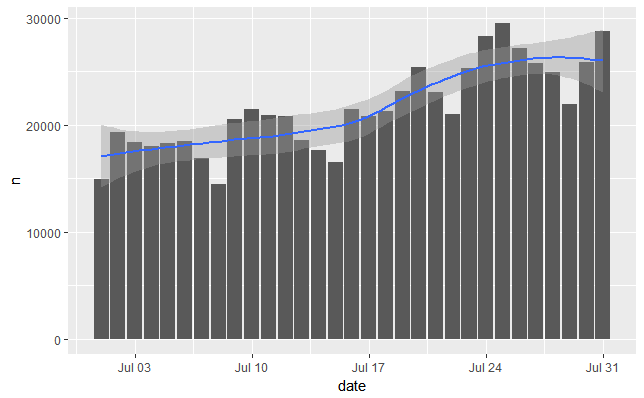

# 3 Calculating User Features

## 3.1 The `highly_active` feature

In the absence of an “objective” measure or threshold to describe an “active” customer we must rely on relative ranking using the following steps:

### 3.1.1 Step 1: Count per-user impressions

We count the number of impressions per customer during the entire month. The most straight forward way is to group by `uuid` and count rows:

```r
df_users <- df %>%
  group_by(uuid) %>%
  summarize(imp_count = n())
df_users %>% head(5) %>% kable()
```

| uuid | imp_count |
| --- | --- |
| 0000AE02C6B52538D17DFAF66F2ACAF1 | 1 |
| 0000CD03517160EAEDB23A93A16489AE | 1 |
| 0000F516516CD22AC34384D65FE369B6 | 4 |
| 0000FBBCD26E0934C890EF3BE71B3122 | 1 |
| 00011B831B460DD8EF00C3214E1F794F | 1 |

### 3.1.2 Step 2: Establishing a threshold for `highly_active` definition

The summary statistics of the impression count below shows that most users have only a single impression in the data, however there’s a small group of users with a very high impression count and possibly some outliers (a good clue is the fact that the mean value is higher than the 75’th percentile).

```r
df_users %>% select(imp_count) %>% summary()
```

```
   imp_count
 Min.   :  1.000
 1st Qu.:  1.000
 Median :  1.000
 Mean   :  2.601
 3rd Qu.:  2.000
 Max.   :923.000
```

This is also clearly visible when looking at a simple histogram:

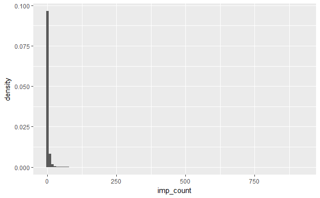

```r
df_users %>%
  ggplot(aes(x = imp_count, y = ..density..)) +
    geom_histogram(bins = 100)
```

A slightly different perspective (looking at a logarithmic scale) reveals that while the group of users with high impression count is small, but the skewness of the distribution is not the result of a single outlier. The the fact that we have users with counts across the scale means that there does not seem to be a “natural” threshold that will classify users as “highly active”.

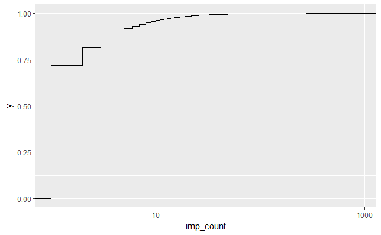

```r
df_users %>%
  ggplot(aes(x = imp_count)) +
    stat_ecdf(geom = 'step') +
    scale_x_log10()
```

I therefore use conventional wisdom and try to set the threshold by quantiles:

```r
probs <- c(0.01 * 90:98, 0.001 * 990:1000)
df_users %>%
  select(imp_count) %>%
  unlist() %>%
  quantile(probs = probs)
```

```
  90%   91%   92%   93%   94%   95%   96%   97%   98%   99% 99.1% 99.2%
    5     5     6     6     7     8    10    12    16    26    27    29
99.3% 99.4% 99.5% 99.6% 99.7% 99.8% 99.9%  100%
   31    34    38    43    52    65    92   923
```

There’s still an order of magnitude difference between the max count and even the 99’th percentile. This suggests that the data may contain two distinct phenomena:

1. Users that are indeed highly active, with impressions count > 10.
2. Suspicious cases (probably data errors, or bots) with impression count > 100.

For the purpose of this exercise I will group the 2 together. Starting from the beginning we can extend the code to include the definition:

```r
df_users <- df %>%
  group_by(uuid) %>%
  summarize(imp_count = n()) %>%
  ## Adding the threshold
  mutate(highly_active = imp_count > 10)
```

Plotting the histogram:

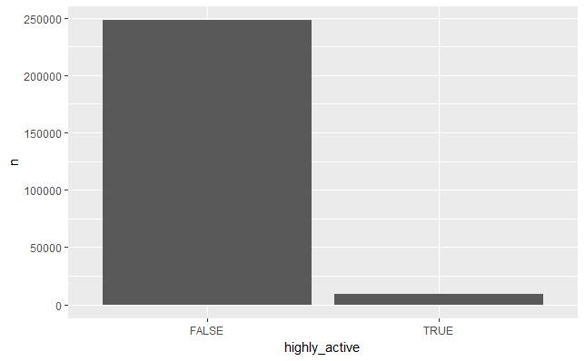

```r
df_users %>%
  count(highly_active) %>%
  ggplot(aes(x = highly_active, y = n)) + geom_bar(stat = 'identity')
```

## 3.2 The `multiple_days` feature

This feature can be calculated by looking only on the date part in the `ts` time-stamp and counting distinct values:

```r
df_users <- df %>%
  ## Adding a "date only" field
  mutate(imp_date = as.Date(ts)) %>%
  group_by(uuid) %>%
  ## count distinct dates
  summarize(active_days = n_distinct(imp_date)) %>%
  ## mark users with more than a single day
  mutate(multiple_days = active_days > 1)
```

Plotting the histogram

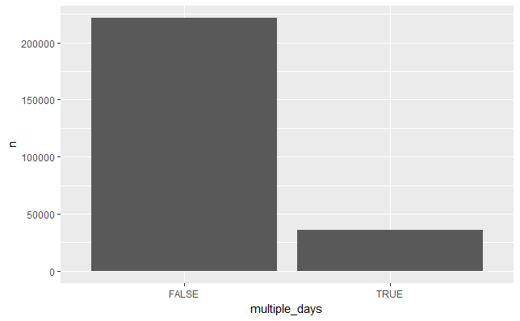

```r
df_users %>%
  count(multiple_days) %>%
  ggplot(aes(x = multiple_days, y = n)) + geom_bar(stat = 'identity')
```

## 3.3 The `weekday_biz` feature

I define weekday business hours as Mon - Fri, 08:00 - 17:00. Using a similar approach I calculate for each user the % of impressions that occurred in this time window:

```r
df_users <- df %>%
  mutate(
    ## We add the weekday and hour for criteria calculation
    imp_weekday = wday(ts),
    imp_hour = hour(ts),
    imp_weekday_biz = if_else(
      imp_weekday > 1 & imp_weekday < 7 & imp_hour >= 8 & imp_hour <=17, 1, 0)
    ) %>%
  group_by(uuid) %>%
  summarize(
    ## Count total impressions
    imp_count = n(),
    ## And count impressions that answer the criteria
    weekday_biz_count = sum(imp_weekday_biz)
    ) %>%
  mutate(
    weekday_biz_prop = weekday_biz_count / imp_count,
    weekday_biz = weekday_biz_prop > 0.5
    )
```

In order to decide on a proper threshold for the TRUE/FALSE definition, let’s observe the distribution of percentages:

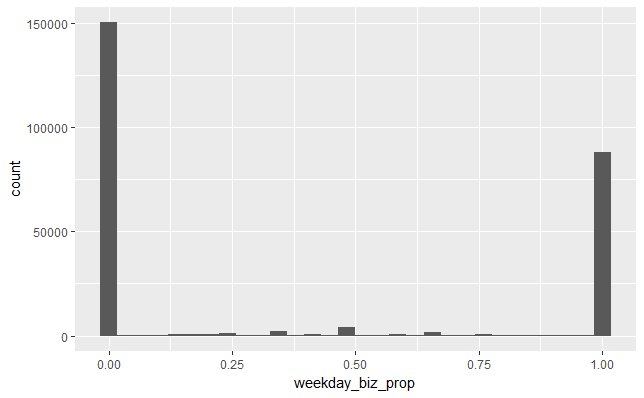

```r
df_users %>%
  ggplot(aes(x = weekday_biz_prop)) + geom_histogram()
```

Unlike the `highly_active` feature, it would seem that users are concentrate their activity either in the business hours or outside the business hours (with only a few users splitting their time in between). A reasonable threshold would therefore be 0.5 (was calculated above).

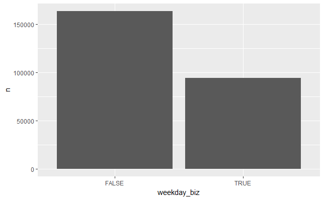

```r
df_users %>%
  count(weekday_biz) %>%
  ggplot(aes(x = weekday_biz, y = n)) + geom_bar(stat = 'identity')
```

## 3.4 The additional feature: `shared_computer`

An interesting way to gain insight into the way customers engage with a website is to step outside the framework of a single `uuid` and try to observe how users relate to one another. In this case the feature I chose to explore is how users are connected to one another via their use of the same IP address.

The first step is to understand how may users use a single IP

```r
df_IP <- df %>%
  group_by(hashed_ip) %>%
  summarise(
    imp_count = n(),
    user_count = n_distinct(uuid)
  )
```

```r
df_IP %>%
  select(imp_count, user_count) %>%
  summary()
```

```
   imp_count         user_count
 Min.   :  1.000   Min.   :  1.00
 1st Qu.:  1.000   1st Qu.:  1.00
 Median :  1.000   Median :  1.00
 Mean   :  2.472   Mean   :  1.09
 3rd Qu.:  2.000   3rd Qu.:  1.00
 Max.   :801.000   Max.   :182.00
```

Focusing on the distribution of user count, it would seem that the majority of IP address are only ever used by a single user:

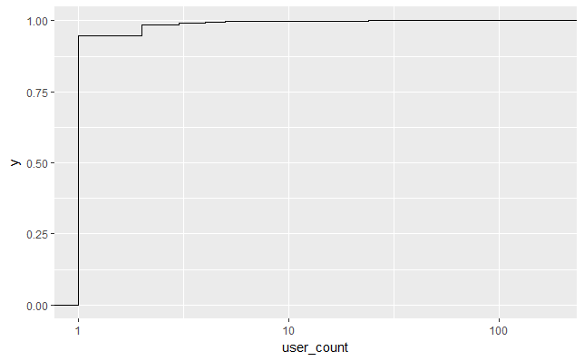

```r
df_IP %>%
  ggplot(aes(x = user_count)) +
    stat_ecdf(geom = 'step') +
    scale_x_log10()
```

We can now match every single impression with the IP information, and see what proportion of user impressions was made on shared IPs (with `user_count` > 1). The code below describes the complete calculation of all features

```r
df_users <- df %>%
  ## matching to the IP data and identify shared IPs
  left_join(
    df %>%
      group_by(hashed_ip) %>%
      summarise(
        IP_imp_count = n(),
        IP_user_count = n_distinct(uuid)
        ),
    by = c('hashed_ip' = 'hashed_ip')
    ) %>%
  mutate(shared_IP = IP_user_count > 1) %>%
  group_by(uuid) %>%
  ## aggregating the shared_IP counts
  summarize(
    imp_count = n(),
    shared_IP_count = sum(shared_IP)) %>%
  ## Calculate proprtion of shared IP impressions
  mutate(
    shared_IP_prop = shared_IP_count / imp_count,
    shared_IP_user = shared_IP_prop > 0.5
    )
```

As before, the distribution of the percentages will allow us to make a more informed decision on the nature of the calculated feature:

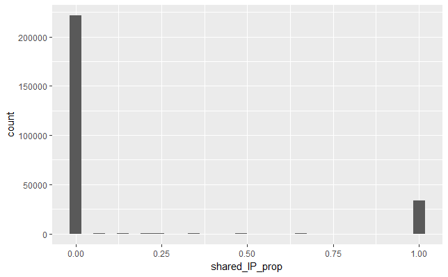

```r
df_users %>%
  ggplot(aes(shared_IP_prop)) + geom_histogram()
```

Since most users either use a unique IP or a shared IP for all of their impressions, we can set a threshold at 0.5 (as calculated above) and make this into a binary TRUE/FALSE feature:

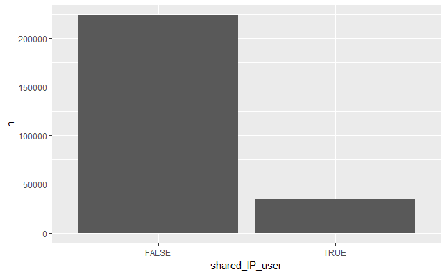

```r
df_users %>%
  count(shared_IP_user) %>%
  ggplot(aes(x = shared_IP_user, y = n)) + geom_bar(stat = 'identity')
```

## 3.5 The final code

With a cleanup stage at the end and some documentation in the comments:

```r
df_users <- df %>%
  ## pre-calculating some features required for later calculations
  mutate(
    ## extract date from the timestamp
    imp_date = as.Date(ts),
    ## Extract day-of-week
    imp_weekday = wday(ts),
    ## Extract hour
    imp_hour = hour(ts),
    ## define "weekday business hour" criteria fora single impression
    imp_weekday_biz = if_else(
      imp_weekday > 1 & imp_weekday < 7 & imp_hour >= 8 & imp_hour <=17, 1, 0)
    ) %>%
  left_join(
    ## Aggregate impressions by IP and count impressions / distinct users
    df %>%
      group_by(hashed_ip) %>%
      summarise(
        IP_imp_count = n(),
        IP_user_count = n_distinct(uuid)
        ),
    by = c('hashed_ip' = 'hashed_ip')
    ) %>%
  ## define the criteria for a shared IP (>1 uuid)
  mutate(shared_IP = IP_user_count > 1) %>%
  ## Aggregate impressions by uuid
  group_by(uuid) %>%
  summarize(
    imp_count = n(),
    active_days = n_distinct(imp_date),
    weekday_biz_count = sum(imp_weekday_biz),
    shared_IP_count = sum(shared_IP)
    ) %>%
  ## Calcuate thresholds as set by previous analysis
  mutate(
    highly_active = imp_count > 10,
    multiple_days = active_days > 1,
    weekday_biz_prop = weekday_biz_count / imp_count,
    weekday_biz = weekday_biz_prop > 0.5,
    shared_IP_prop = shared_IP_count / imp_count,
    shared_IP_user = shared_IP_prop > 0.5
    ) %>%
  # Cleaup
  select(-imp_count, -active_days, -weekday_biz_count, -shared_IP_count, -weekday_biz_prop, -shared_IP_prop)
```

And the resulting table:

```r
df_users %>% head(5) %>% kable()
```

| uuid | highly_active | multiple_days | weekday_biz | shared_IP_user |
| --- | --- | --- | --- | --- |
| 0000AE02C6B52538D17DFAF66F2ACAF1 | FALSE | FALSE | FALSE | FALSE |
| 0000CD03517160EAEDB23A93A16489AE | FALSE | FALSE | FALSE | FALSE |
| 0000F516516CD22AC34384D65FE369B6 | FALSE | FALSE | FALSE | FALSE |
| 0000FBBCD26E0934C890EF3BE71B3122 | FALSE | FALSE | FALSE | FALSE |
| 00011B831B460DD8EF00C3214E1F794F | FALSE | FALSE | FALSE | FALSE |

# 4 A note on working with larger datasets

To allow more efficient processing of the feature extraction process (and to also demonstrate how the following actions can be scaled up to Spark / Hadoop machines) the first step is to partition the data (or “nest” in R terminology). Since we are not going to explore cross-user features at this time, we can partition data by `uuid`

```r
t(dim(df_users_nested))
```

```
       [,1] [,2]
[1,] 257354    2
```

The new data structure contains the key `uuid` and a list of data frames (one per user).

```r
df_users_nested %>% colnames()
```

```
[1] "uuid" "data"
```

We can now calculate the same features with “map / reduce” approach that can be easily distributed and parallelized. For example, counting impressions per user:

```r
df_users_nested <- df_users_nested %>%
  mutate(
    imp_count = map_int(.x = data, .f = function(x) dim(x)[1])
    )
df_users_nested %>% select(-data, -uuid) %>% summary()
```

```
   imp_count
 Min.   :  1.000
 1st Qu.:  1.000
 Median :  1.000
 Mean   :  2.601
 3rd Qu.:  2.000
 Max.   :923.000
```

Which shows exactly the same results as before.